# Perfil sindrômico e exposição à caça em comunidades extrativistas

- Mostrar o código
- Esconder o código
- Ver o código fonte

RESEX Tapajós-Arapiuns — Análise exploratória

Autor

Ayrton

Data de Publicação

28 de abril de 2026

# 1 Introdução

Este documento apresenta uma análise exploratória do perfil sindrômico de famílias em comunidades caçadoras da **Reserva Extrativista Tapajós-Arapiuns**, no Pará. A análise busca responder a seis perguntas principais:

**Perguntas de pesquisa**

1. **P1** — Qual é o perfil sindrômico das famílias na RESEX?
2. **P2** — Existe gradiente de exposição a fauna potencialmente infectada entre as famílias?
3. **P3** — A intensidade da caça prediz síndrome infecciosa aguda?
4. **P4** — Síndrome aguda e exposição à caça são fenômenos geograficamente dissociados?
5. **P5** — Composição etária e saneamento explicam o gradiente observado?
6. **P6** — A atividade do chefe da família diferencia os clusters sindrômicos?

**Dado:** 567 famílias, 35 comunidades  
**Unidade de análise:** domicílio/família  
**Abordagem:** cada síndrome = ao menos um membro da família relatou o problema, mantendo consistência com os dados de exposição à caça.

# 2 Preparação dos dados

**Ver código**

```r
saude <- list_of_tables$Saúde

# Variáveis com identificação incerta — excluídas da análise
vars_nao_identificadas <- c(
  "TDORPEIT", "TVMEDIO", "TVNAOSAB",
  "FALTA", "FALTCDOR", "FCDORCAB", "FCDORMUS", "FCBOLVRM", "FALTREM",
  "TOCATPEIT", "TOQUENTU", "TOPOEIR",
  "BSSIM", "AOSIM", "REMFARM", "REMCASEI", "VIS_SAU", "OBIT_DEC",
  "TRAT_INA", "Dia_Quad", "Reza", "H_recuper", "Obt_s_id", "Obt_c_id",
  "ANECLAMP", "ANSINPAN", "ANINVEST", "ANPOSTUMOR"
)

problemas_saude_homem  <- setdiff(names(saude)[startsWith(names(saude), "H")], vars_nao_identificadas)
problemas_saude_mulher <- setdiff(names(saude)[startsWith(names(saude), "M")], vars_nao_identificadas)
problemas_saude_idoso  <- setdiff(names(saude)[startsWith(names(saude), "I")], vars_nao_identificadas)
problemas_saude_crianc <- setdiff(names(saude)[startsWith(names(saude), "C")], vars_nao_identificadas)
problemas_saude_tosse  <- names(saude)[names(saude) %in% c("TOSSECA", "TOSSMUCO", "TOSINUS", "TSECMUCO")]
```

# 3 P1 — Perfil sindrômico das famílias

## 3.1 Construção das síndromes

Sete síndromes foram definidas a partir dos sintomas autorreferidos, agrupando condições com mecanismo fisiopatológico comum. A lógica de qualquer membro da família garante que o perfil domiciliar de adoecimento seja capturado, não apenas o individual.

**Ver código**

```r
saude_cluster <- saude %>%
  mutate(
    sind_resp = if_any(c("HASMA", "MASMA", "IASMA", "CASMA",
                         "HGRIPE", "MGRIPE", "IGRIPE", "CGRIPE",
                         "HRINITE", "MRINIALE",
                         "HSINUSIT", "MSINUSIT", "ISINUSIT", "CSINUSIT",
                         "HTOSSE", "MTOSSE", "ITOSSE", "CTOSSE",
                         "TOSSECA", "TOSSMUCO", "TSECMUCO", "TOSINUS"), ~ . == 1),
    sind_febril = if_any(c("HFEBRE", "MFEBRE", "IFEBRE", "CFEBRE",
                           "HGRIPE", "MGRIPE", "IGRIPE", "CGRIPE",
                           "HVIROSE", "MVIROSE"), ~ . == 1),
    sind_osteo = if_any(c("HREUMAT", "MREUMAT", "IREUMAT", "CREUMAT",
                          "HDORCAB", "MDORCAB", "IDORCAB", "CADORCAB",
                          "HDORMUSC", "MDORMUSC", "IDORMUSC", "CDORMUSC",
                          "HDORCOLU", "MDORCOLU", "IDORCOLU",
                          "HDORJOEL", "IDORJOEL"), ~ . == 1),
    sind_gi = if_any(c("HDIARREIA", "MDIARREIA", "IDIARREIA", "CDIAREIA",
                       "HESTOMAG", "MGASTRIT", "IGASTRIT",
                       "HVOMIT", "MVOMIT", "IVOMIT", "CVOMIT",
                       "HDORESTG"), ~ . == 1),
    sind_cardiomet = if_any(c("HPRESALT", "MPRESALT", "IPRESALT",
                              "HDIABET", "MDIABETE", "IDIABETE",
                              "HPROBCOL", "MPROBCOL",
                              "HPROBCOR", "MCORACGD", "HCORACGD"), ~ . == 1),
    sind_neuro = if_any(c("ANPERMOV", "ANPERCON", "ANDIFALA",
                          "ANPERVIS", "ANPERAUD", "ANNEUROL",
                          "ANDEPRES", "ANTONTURA", "ANMEMORI"), ~ . == 1),
    sind_derm_paras = if_any(c("HMALARIA", "HHANSENI",
                               "IINFCRIM", "IINFCURI",
                               "IMICOSE", "CAMICOSE", "TMICOSE",
                               "CINFRESAG"), ~ . == 1)
  ) %>%
  mutate(across(starts_with("sind_"), as.integer))
```

## 3.2 Clustering k-means

Cada família foi representada como um vetor binário de sete dimensões (uma por síndrome). O k-means agrupou famílias com perfis similares. A escolha de k foi orientada pelo método do cotovelo e validada pelo silhouette médio.

**Ver código**

```r
vars_sind <- c("sind_resp", "sind_febril", "sind_osteo",
               "sind_gi", "sind_cardiomet", "sind_neuro", "sind_derm_paras")

mat_cluster <- saude_cluster %>%
  select(Amostra, Comunidade, all_of(vars_sind)) %>%
  drop_na(all_of(vars_sind))
```

**Ver código**

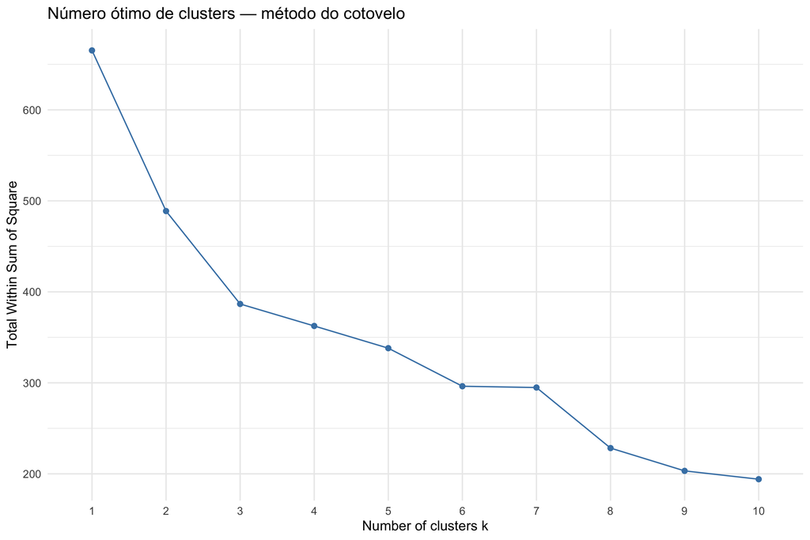

Método do cotovelo para escolha do número de clusters. A queda mais expressiva ocorre de k=1 para k=2.

```r
set.seed(42)
fviz_nbclust(
  mat_cluster %>% select(all_of(vars_sind)),
  kmeans, method = "wss", k.max = 10
) + labs(title = "Número ótimo de clusters — método do cotovelo") +
  theme_minimal()
```

**Ver código**

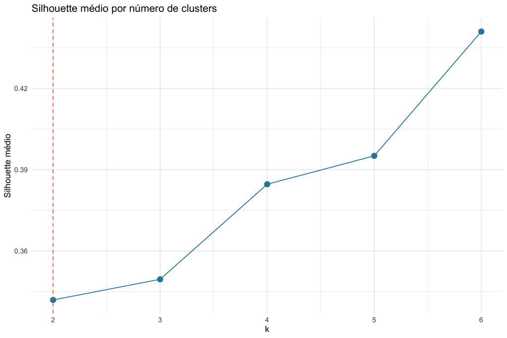

Silhouette médio por número de clusters. k=2 apresenta separação razoável (0.34) com maior parcimônia.

```r
sil_scores <- map_dfr(2:6, function(k) {
  set.seed(42)
  km_tmp <- kmeans(mat_cluster %>% select(all_of(vars_sind)),
                   centers = k, nstart = 25, iter.max = 100)
  ss <- silhouette(km_tmp$cluster, dist(mat_cluster %>% select(all_of(vars_sind))))
  tibble(k = k, silhouette = mean(ss[, 3]))
})

ggplot(sil_scores, aes(x = k, y = silhouette)) +
  geom_line(color = "#2E86AB") +
  geom_point(size = 3, color = "#2E86AB") +
  geom_vline(xintercept = 2, linetype = "dashed", color = "tomato") +
  theme_minimal() +
  labs(title = "Silhouette médio por número de clusters",
       x = "k", y = "Silhouette médio")
```

**Ver código**

```r
set.seed(42)
km <- kmeans(
  mat_cluster %>% select(all_of(vars_sind)),
  centers = 2, nstart = 25, iter.max = 100
)

mat_cluster <- mat_cluster %>%
  mutate(
    cluster = factor(km$cluster),
    cluster_label = case_when(
      cluster == 1 ~ "Sem síndrome aguda predominante",
      cluster == 2 ~ "Síndrome gripal/infecciosa aguda"
    )
  )
```

**Ver código**

```
  cluster size ave.sil.width
1       1  292          0.32
2       2  275          0.36
```

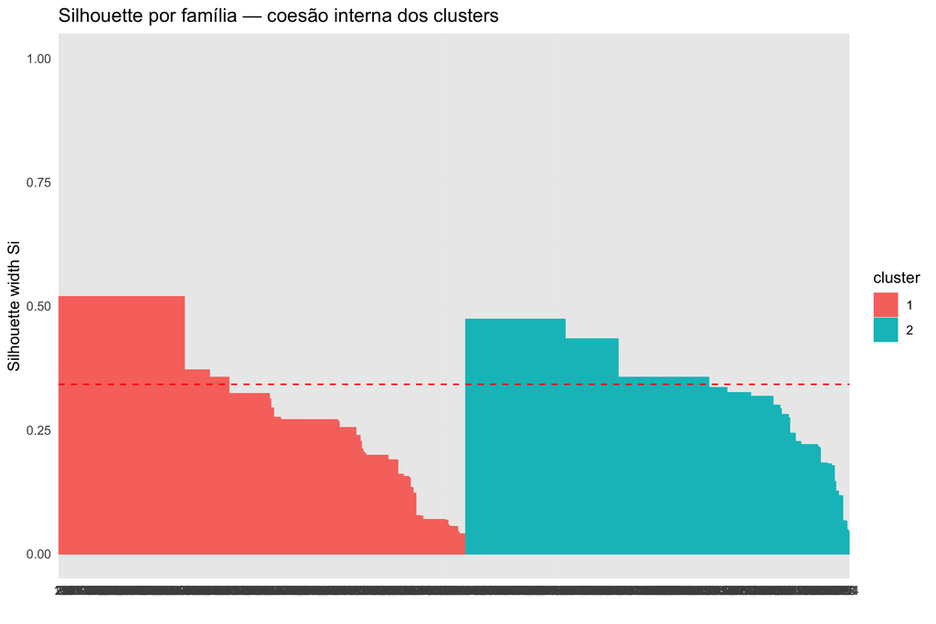

Silhouette por família. Silhouette médio = 0.34, sem valores negativos — separação moderada e aceitável para dados binários.

```r
sil <- silhouette(as.integer(mat_cluster$cluster),
                  dist(mat_cluster %>% select(all_of(vars_sind))))
fviz_silhouette(sil) +
  theme_minimal() +
  labs(title = "Silhouette por família — coesão interna dos clusters")
```

**Ver código**

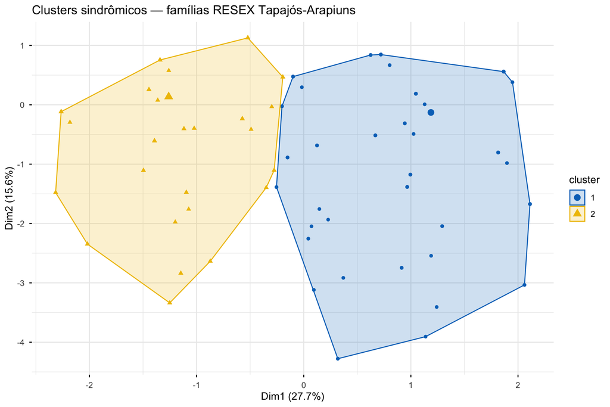

Projeção PCA dos clusters. Os dois grupos ocupam regiões distintas no espaço multivariado com sobreposição mínima na fronteira.

```r
fviz_cluster(km,
             data = mat_cluster %>% select(all_of(vars_sind)),
             geom = "point", ellipse.type = "convex",
             palette = "jco", ggtheme = theme_minimal()) +
  labs(title = "Clusters sindrômicos — famílias RESEX Tapajós-Arapiuns")
```

## 3.3 Perfil dos clusters

**Ver código**

```r
# Criar tabela de composição das síndromes
tabela_sindromes <- data.frame(
  Síndrome = c("sind_resp", "sind_febril", "sind_osteo",
               "sind_gi", "sind_cardiomet", "sind_neuro", "sind_derm_paras"),

  Descrição = c("Síndrome Respiratória", "Síndrome Febril", "Síndrome Osteomuscular",
                "Síndrome Gastrointestinal", "Síndrome Cardiometabólica",
                "Síndrome Neurológica", "Síndrome Dermatológica/Parasitária"),

  Componentes = c(
    "HASMA, MASMA, IASMA, CASMA, HGRIPE, MGRIPE, IGRIPE, CGRIPE, HRINITE, MRINIALE, HSINUSIT, MSINUSIT, ISINUSIT, CSINUSIT, HTOSSE, MTOSSE, ITOSSE, CTOSSE, TOSSECA, TOSSMUCO, TSECMUCO, TOSINUS",

    "HFEBRE, MFEBRE, IFEBRE, CFEBRE, HGRIPE, MGRIPE, IGRIPE, CGRIPE, HVIROSE, MVIROSE",

    "HREUMAT, MREUMAT, IREUMAT, CREUMAT, HDORCAB, MDORCAB, IDORCAB, CADORCAB, HDORMUSC, MDORMUSC, IDORMUSC, CDORMUSC, HDORCOLU, MDORCOLU, IDORCOLU, HDORJOEL, IDORJOEL",

    "HDIARREIA, MDIARREIA, IDIARREIA, CDIAREIA, HESTOMAG, MGASTRIT, IGASTRIT, HVOMIT, MVOMIT, IVOMIT, CVOMIT, HDORESTG",

    "HPRESALT, MPRESALT, IPRESALT, HDIABET, MDIABETE, IDIABETE, HPROBCOL, MPROBCOL, HPROBCOR, MCORACGD, HCORACGD",

    "ANPERMOV, ANPERCON, ANDIFALA, ANPERVIS, ANPERAUD, ANNEUROL, ANDEPRES, ANTONTURA, ANMEMORI",

    "HMALARIA, HHANSENI, IINFCRIM, IINFCURI, IMICOSE, CAMICOSE, TMICOSE, CINFRESAG"
  ),

  Quantidade = c(22, 10, 17, 12, 11, 9, 8)
)

# Visualizar tabela
knitr::kable(tabela_sindromes, caption = "Composição das Síndromes Clínicas") %>%
    kable_styling(bootstrap_options = c("striped", "hover", "condensed", "responsive"))
```

Composição das Síndromes Clínicas

| Síndrome | Descrição | Componentes | Quantidade |
| --- | --- | --- | --- |
| sind_resp | Síndrome Respiratória | HASMA, MASMA, IASMA, CASMA, HGRIPE, MGRIPE, IGRIPE, CGRIPE, HRINITE, MRINIALE, HSINUSIT, MSINUSIT, ISINUSIT, CSINUSIT, HTOSSE, MTOSSE, ITOSSE, CTOSSE, TOSSECA, TOSSMUCO, TSECMUCO, TOSINUS | 22 |
| sind_febril | Síndrome Febril | HFEBRE, MFEBRE, IFEBRE, CFEBRE, HGRIPE, MGRIPE, IGRIPE, CGRIPE, HVIROSE, MVIROSE | 10 |
| sind_osteo | Síndrome Osteomuscular | HREUMAT, MREUMAT, IREUMAT, CREUMAT, HDORCAB, MDORCAB, IDORCAB, CADORCAB, HDORMUSC, MDORMUSC, IDORMUSC, CDORMUSC, HDORCOLU, MDORCOLU, IDORCOLU, HDORJOEL, IDORJOEL | 17 |
| sind_gi | Síndrome Gastrointestinal | HDIARREIA, MDIARREIA, IDIARREIA, CDIAREIA, HESTOMAG, MGASTRIT, IGASTRIT, HVOMIT, MVOMIT, IVOMIT, CVOMIT, HDORESTG | 12 |
| sind_cardiomet | Síndrome Cardiometabólica | HPRESALT, MPRESALT, IPRESALT, HDIABET, MDIABETE, IDIABETE, HPROBCOL, MPROBCOL, HPROBCOR, MCORACGD, HCORACGD | 11 |
| sind_neuro | Síndrome Neurológica | ANPERMOV, ANPERCON, ANDIFALA, ANPERVIS, ANPERAUD, ANNEUROL, ANDEPRES, ANTONTURA, ANMEMORI | 9 |
| sind_derm_paras | Síndrome Dermatológica/Parasitária | HMALARIA, HHANSENI, IINFCRIM, IINFCURI, IMICOSE, CAMICOSE, TMICOSE, CINFRESAG | 8 |

**Ver código**

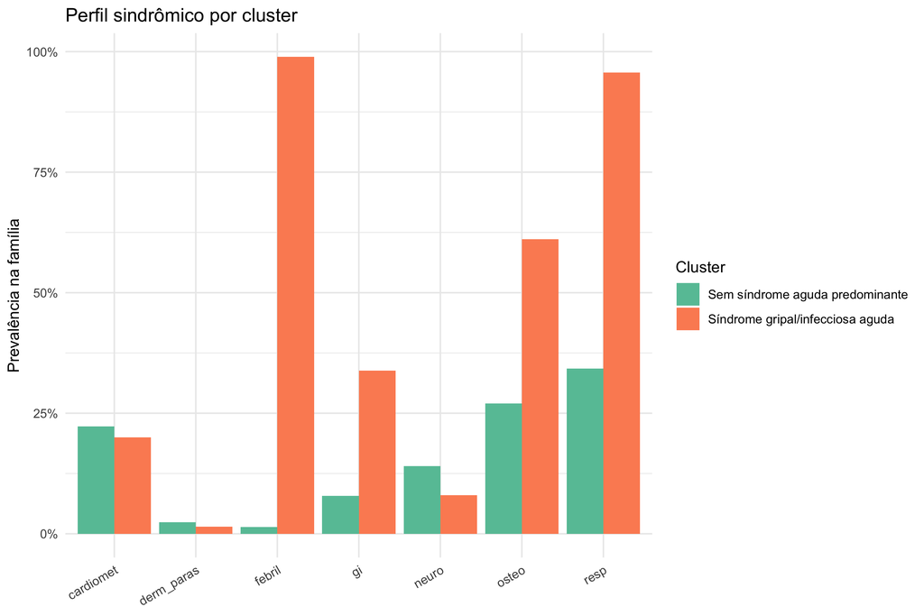

Prevalência média de cada síndrome por cluster. O cluster 2 é dominado por síndrome febril (~100%) e respiratória (~95%).

```r
mat_cluster %>%
  group_by(cluster_label) %>%
  summarise(across(all_of(vars_sind), mean, na.rm = TRUE), n = n()) %>%
  pivot_longer(-c(cluster_label, n), names_to = "Síndrome", values_to = "Prevalência") %>%
  mutate(Síndrome = str_remove(Síndrome, "sind_")) %>%
  ggplot(aes(x = Síndrome, y = Prevalência, fill = cluster_label)) +
  geom_col(position = "dodge") +
  scale_y_continuous(labels = percent) +
  scale_fill_brewer(palette = "Set2") +
  theme_minimal() +
  theme(axis.text.x = element_text(angle = 30, hjust = 1)) +
  labs(title = "Perfil sindrômico por cluster",
       fill = "Cluster", x = NULL, y = "Prevalência na família")
```

**Ver código**

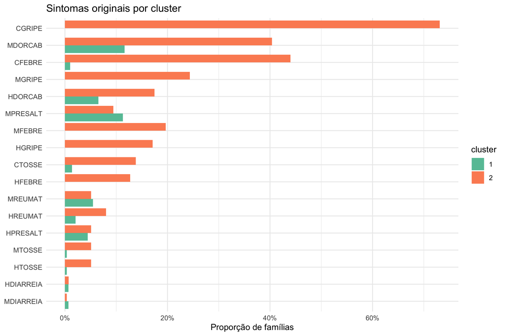

Sintomas originais por cluster. CGRIPE (~70%) e CFEBRE (~43%) dominam o cluster 2, sugerindo o perfil de síndrome gripal com forte componente pediátrico.

```r
vars_originais <- c("HGRIPE", "MGRIPE", "CGRIPE",
                    "HFEBRE", "MFEBRE", "CFEBRE",
                    "HREUMAT", "MREUMAT",
                    "HDORCAB", "MDORCAB",
                    "HTOSSE", "MTOSSE", "CTOSSE",
                    "HPRESALT", "MPRESALT",
                    "HDIARREIA", "MDIARREIA")

saude %>%
  left_join(mat_cluster %>% select(Amostra, cluster), by = "Amostra") %>%
  group_by(cluster) %>%
  summarise(across(all_of(vars_originais), ~ mean(., na.rm = TRUE))) %>%
  pivot_longer(-cluster, names_to = "Variavel", values_to = "Prevalencia") %>%
  ggplot(aes(x = reorder(Variavel, Prevalencia), y = Prevalencia, fill = cluster)) +
  geom_col(position = "dodge") +
  scale_y_continuous(labels = percent) +
  scale_fill_brewer(palette = "Set2") +
  coord_flip() +
  theme_minimal() +
  labs(title = "Sintomas originais por cluster",
       x = NULL, y = "Proporção de famílias")
```

**Interpretação — P1**

Dois clusters sindrômicos emergiram com separação moderada (silhouette = 0.34):

- **Cluster 1 — Sem síndrome aguda predominante** (n = 292, 51%): queixas crônicas difusas, sem episódio infeccioso agudo dominante.
- **Cluster 2 — Síndrome gripal/infecciosa aguda** (n = 275, 49%): febre e gripe em múltiplos membros — especialmente crianças.

## 3.4 Distribuição por comunidade

**Ver código**

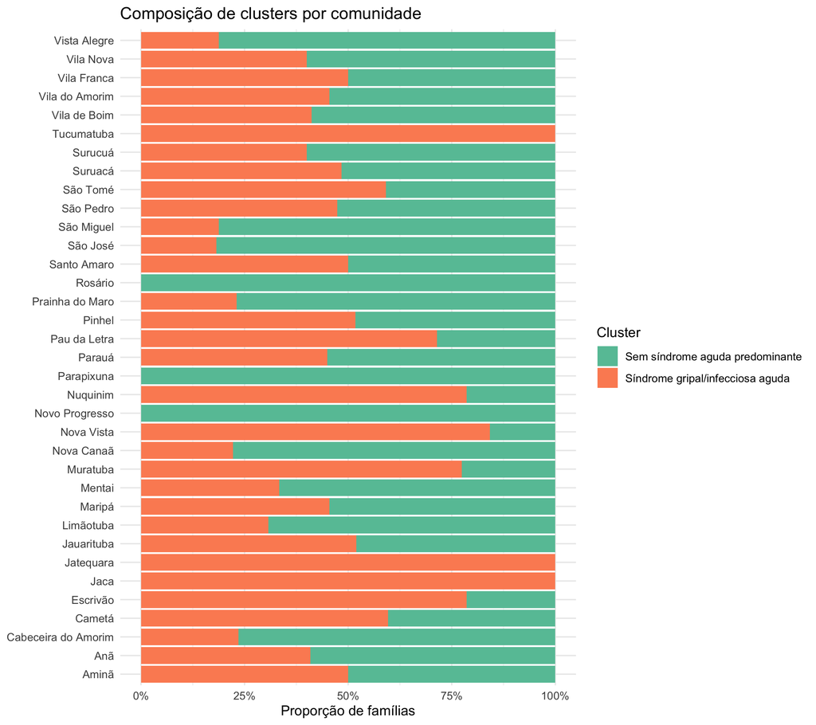

Composição dos clusters por comunidade. A distribuição não é homogênea (χ²=78, p<0,001).

```r
mat_cluster %>%
  count(Comunidade, cluster_label) %>%
  group_by(Comunidade) %>%
  mutate(prop = n / sum(n)) %>%
  ggplot(aes(x = Comunidade, y = prop, fill = cluster_label)) +
  geom_col() +
  scale_y_continuous(labels = percent) +
  scale_fill_brewer(palette = "Set2") +
  coord_flip() +
  theme_minimal() +
  labs(title = "Composição de clusters por comunidade",
       x = NULL, y = "Proporção de famílias", fill = "Cluster")
```

**Ver código**

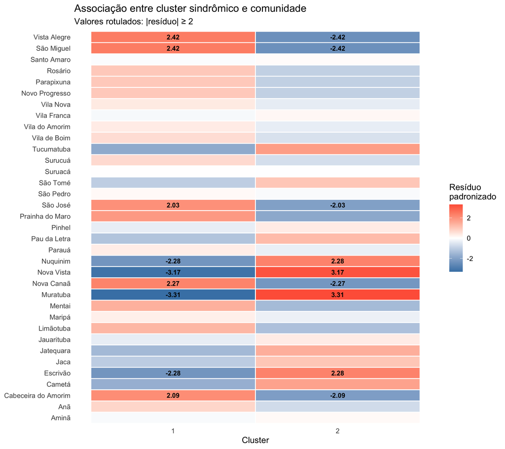

Resíduos padronizados do qui-quadrado. Valores rotulados (|resíduo| ≥ 2) indicam associação significativa entre comunidade e cluster.

```r
chisq_result <- chisq.test(
  table(mat_cluster$Comunidade, mat_cluster$cluster),
  simulate.p.value = TRUE
)

residuos <- chisq_result$stdres
as.data.frame(residuos) %>%
  rename(Comunidade = Var1, Cluster = Var2, Residuo = Freq) %>%
  mutate(label = ifelse(abs(Residuo) >= 2, round(Residuo, 2), NA)) %>%
  ggplot(aes(x = Cluster, y = reorder(Comunidade, Residuo), fill = Residuo)) +
  geom_tile(color = "white", linewidth = 0.5) +
  geom_text(aes(label = label), size = 3, fontface = "bold") +
  scale_fill_gradient2(low = "steelblue", mid = "white", high = "tomato",
                       midpoint = 0, name = "Resíduo\npadronizado") +
  theme_minimal() +
  theme(panel.grid = element_blank()) +
  labs(title = "Associação entre cluster sindrômico e comunidade",
       subtitle = "Valores rotulados: |resíduo| ≥ 2",
       x = "Cluster", y = NULL)
```

**Resultado**

Distribuição heterogênea entre comunidades: χ² = 78, p < 0,001.  
**Excesso de síndrome aguda:** Muratuba (+3,31), Nova Vista (+3,17), Escrivão (+2,28), Nuquinim (+2,28).  
**Excesso de baixa carga:** São Miguel (+2,42), Vista Alegre (+2,42), Nova Canaã (+2,27).

# 4 P2 — Gradiente de exposição zoonótica

Antes de testar se a caça prediz doença, caracterizamos o cenário de exposição. Se o risco existe e é graduado, a pergunta seguinte é se ele se traduz em síndrome clínica detectável.

**Ver código**

```r
caca <- list_of_tables$Caça

caca_cluster <- caca %>%
  mutate(
    n_presas = CPCAITIT + CPQUEIXA + CPVEADO + CPCUTIA + CPPACA +
               CPTATU + CPMACACO + CPMACPRG + CPGUARIB +
               CP_AVES + CPMUTUM + CPJABUTI,
    caca_primata   = if_any(c("CPMACACO", "CPMACPRG", "CPGUARIB", "CPXAUIM"), ~ . == 1),
    freq_alta      = if_any(c("FCTODODI", "FC1xSEM", "FC2A3xSM"), ~ . == 1),
    contato_doente = if_any(c("PCSEMPRE", "PCSIM", "PCDVZQD"), ~ . == 1),
    consume_doente = if_any(c("COZINCOM", "ANIMCOME"), ~ . == 1),
    caca_ativa     = CFSIM == 1,
    perfil_exposicao = case_when(
      freq_alta == 1 & (contato_doente == 1 | consume_doente == 1) ~ "Alta exposição",
      freq_alta == 1 & contato_doente == 0 & consume_doente == 0   ~ "Exposição moderada",
      freq_alta == 0 & contato_doente == 0 & consume_doente == 0   ~ "Baixa exposição",
      TRUE                                                          ~ "Exposição pontual"
    ),
    n_sinais_animal  = FERIDA + VERMES + PARASIT + SINT_DO +
                       MAGRA + TUMOR + MANCH_BR + URA + MICROB,
    animal_com_sinal = as.integer(n_sinais_animal >= 1)
  ) %>%
  mutate(across(c(caca_primata, freq_alta, contato_doente,
                  consume_doente, caca_ativa), as.integer))
```

**Ver código**

```r
caca_cluster %>%
  summarise(
    `Caça ativa`        = percent(mean(caca_ativa,     na.rm = TRUE), accuracy = 1),
    `Primatas`          = percent(mean(caca_primata,   na.rm = TRUE), accuracy = 1),
    `Alta frequência`   = percent(mean(freq_alta,      na.rm = TRUE), accuracy = 1),
    `Contato c/ doente` = percent(mean(contato_doente, na.rm = TRUE), accuracy = 1),
    `Consumo de doente` = percent(mean(consume_doente, na.rm = TRUE), accuracy = 1),
    `Média de presas`   = as.character(round(mean(n_presas, na.rm = TRUE), 1))
  ) %>%
  pivot_longer(everything(), names_to = "Variável", values_to = "Valor") %>%
  kable(align = c("l", "r")) %>%
  kable_styling(bootstrap_options = c("striped", "hover"), full_width = FALSE)
```

Prevalências gerais de exposição à caça.

| Variável | Valor |
| --- | --- |
| Caça ativa | 72% |
| Primatas | 4% |
| Alta frequência | 43% |
| Contato c/ doente | 31% |
| Consumo de doente | 20% |
| Média de presas | 2.7 |

**Ver código**

```r
vars_sinal_zoonotico <- c("FERIDA", "VERMES", "PARASIT", "SINT_DO", "SINT_INF",
                           "MAGRA", "TUMOR", "MANCH_BR", "URA", "MICROB")

caca_cluster %>%
  summarise(across(all_of(vars_sinal_zoonotico),
                   ~ percent(mean(., na.rm = TRUE), accuracy = 1))) %>%
  pivot_longer(everything(), names_to = "Sinal", values_to = "Prevalência") %>%
  kable(align = c("l", "r")) %>%
  kable_styling(bootstrap_options = c("striped", "hover"), full_width = FALSE)
```

Prevalência de sinais de doença nos animais caçados. VERMES é o sinal mais prevalente (12%), sugerindo helmintozoonoses como risco prioritário.

| Sinal | Prevalência |
| --- | --- |
| FERIDA | 4% |
| VERMES | 12% |
| PARASIT | 4% |
| SINT_DO | 3% |
| SINT_INF | 0% |
| MAGRA | 5% |
| TUMOR | 3% |
| MANCH_BR | 1% |
| URA | 4% |
| MICROB | 2% |

**Ver código**

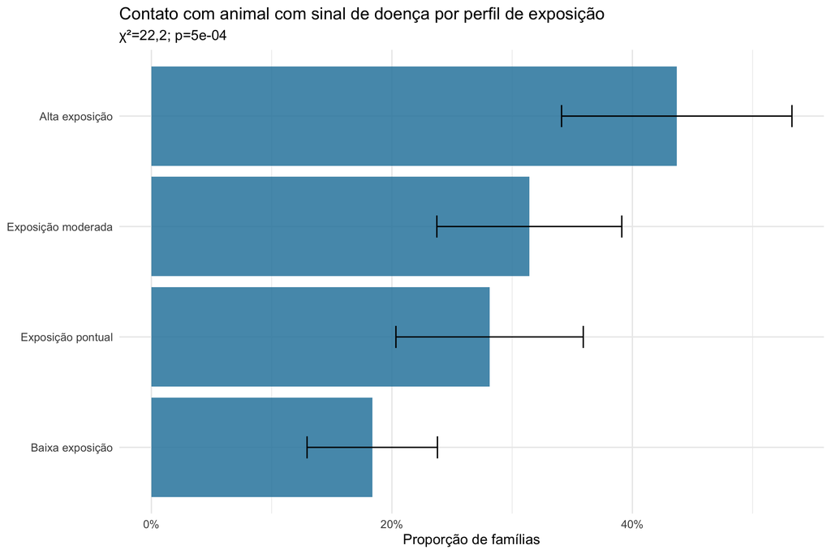

Contato com animal com sinal de doença por perfil de exposição (IC 95%). O gradiente é monotônico e significativo (χ²=22,2; p<0,001): alta exposição = 44% vs baixa exposição = 18%.

```r
chisq_grad <- chisq.test(table(caca_cluster$perfil_exposicao,
                                caca_cluster$animal_com_sinal),
                          simulate.p.value = TRUE)

caca_cluster %>%
  group_by(perfil_exposicao) %>%
  summarise(prop = mean(animal_com_sinal, na.rm = TRUE), n = n()) %>%
  mutate(
    perfil_exposicao = fct_reorder(perfil_exposicao, prop),
    ic_low  = prop - 1.96 * sqrt(prop * (1 - prop) / n),
    ic_high = prop + 1.96 * sqrt(prop * (1 - prop) / n)
  ) %>%
  ggplot(aes(x = perfil_exposicao, y = prop)) +
  geom_col(fill = "#2E86AB", alpha = 0.85) +
  geom_errorbar(aes(ymin = ic_low, ymax = ic_high), width = 0.2) +
  scale_y_continuous(labels = percent) +
  coord_flip() +
  theme_minimal() +
  labs(title = "Contato com animal com sinal de doença por perfil de exposição",
       subtitle = paste0("χ²=22,2; p=", round(chisq_grad$p.value, 4)),
       x = NULL, y = "Proporção de famílias")
```

**Interpretação — P2**

Existe gradiente significativo de exposição zoonótica potencial (χ²=22,2; p<0,001). Famílias de alta exposição têm 44% de contato com animais com sinal de doença, versus 18% nas de baixa exposição. O risco zoonótico potencial existe e é graduado pela intensidade da caça. **A pergunta seguinte é se esse risco se traduz em síndrome clínica detectável.**

# 5 P3 — A caça prediz síndrome infecciosa aguda?

## 5.1 Integração dos dados

**Ver código**

```r
dados_integrados <- mat_cluster %>%
  select(Amostra, Comunidade, cluster, cluster_label) %>%
  left_join(
    caca_cluster %>% select(Amostra, n_presas, caca_primata, freq_alta,
                             contato_doente, consume_doente, caca_ativa,
                             perfil_exposicao, animal_com_sinal, n_sinais_animal),
    by = "Amostra"
  ) %>%
  left_join(list_of_tables$Etário  %>% select(-any_of("Comunidade")), by = "Amostra") %>%
  left_join(list_of_tables$Hábitos %>% select(-any_of("Comunidade")), by = "Amostra") %>%
  left_join(list_of_tables$Casa    %>% select(-any_of("Comunidade")), by = "Amostra") %>%
  left_join(
    list_of_tables$Atividades %>%
      select(Amostra, AGSAUDE, ARTESANAT, COMERC, EXTRAT, PESCA, PROFESSOR, ROÇA),
    by = "Amostra"
  ) %>%
  mutate(
    tem_crianca   = as.integer(CSCRIANC > 0),
    tem_idoso     = as.integer(CSIDOSOS > 0),
    n_membros     = CSCRIANC + CSADOLEN + CSADULTO + CSIDOSOS,
    prop_crianca  = CSCRIANC / n_membros,
    ferve_agua    = as.integer(FERVSIM == 1 | FERVSEMP == 1),
    filtra_agua   = as.integer(FILSIM == 1),
    agua_segura   = as.integer(MICRO == 1),
    agua_rio      = as.integer(RIO == 1),
    casa_precaria = as.integer(BARRO == 1 | PALHA == 1)
  )
```

## 5.2 Nível familiar

**Ver código**

```r
vars_caca <- c("caca_ativa", "freq_alta", "contato_doente", "consume_doente")

tab_caca <- map_dfr(vars_caca, function(v) {
  tab <- table(dados_integrados[[v]], dados_integrados$cluster)
  if (nrow(tab) < 2) return(NULL)
  test <- chisq.test(tab, simulate.p.value = TRUE)
  tibble(
    Variável = v,
    `Cluster 1 (%)` = percent(mean(dados_integrados[[v]][dados_integrados$cluster == 1], na.rm = TRUE), accuracy = 1),
    `Cluster 2 (%)` = percent(mean(dados_integrados[[v]][dados_integrados$cluster == 2], na.rm = TRUE), accuracy = 1),
    `p-valor` = round(test$p.value, 3)
  )
})

tab_caca %>%
  kable(align = c("l", "r", "r", "r")) %>%
  kable_styling(bootstrap_options = c("striped", "hover"), full_width = FALSE) %>%
  row_spec(0, bold = TRUE)
```

Associação entre variáveis de exposição à caça e cluster sindrômico (nível familiar). Nenhuma variável se associa positivamente ao cluster de síndrome aguda.

| Variável | Cluster 1 (%) | Cluster 2 (%) | p-valor |
| --- | --- | --- | --- |
| caca_ativa | 72% | 72% | 0.921 |
| freq_alta | 43% | 43% | 0.931 |
| contato_doente | 34% | 27% | 0.078 |
| consume_doente | 23% | 16% | 0.049 |

**Ver código**

```r
fisher_result <- fisher.test(table(dados_integrados$consume_doente, dados_integrados$cluster))
```

**Resultado — consumo de animal doente**

Teste exato de Fisher: OR = 0.65 (IC95% 0.41–1), p = 0.046.

O efeito é **inverso** ao esperado — famílias que consomem animais doentes têm **menos** síndrome aguda. Isso talvez seja um efeito (uma proxy) do isolamento geográficos?.

**Ver código**

```r
table(dados_integrados$perfil_exposicao,
      dados_integrados$cluster_label) %>%
  prop.table(margin = 1) %>%
  round(2) %>%
  as.data.frame() %>%
  pivot_wider(names_from = Var2, values_from = Freq) %>%
  rename(Perfil = Var1) %>%
  kable(align = c("l", "r", "r")) %>%
  kable_styling(bootstrap_options = c("striped", "hover"), full_width = FALSE)
```

Proporção de famílias em cada cluster por perfil de exposição à caça. Não há padrão — todas as proporções ficam entre 41% e 59%.

| Perfil | Sem síndrome aguda predominante | Síndrome gripal/infecciosa aguda |
| --- | --- | --- |
| Alta exposição | 0.55 | 0.45 |
| Baixa exposição | 0.46 | 0.54 |
| Exposição moderada | 0.49 | 0.51 |
| Exposição pontual | 0.59 | 0.41 |

## 5.3 Nível comunitário

**Ver código**

```r
dados_comunidade <- dados_integrados %>%
  group_by(Comunidade) %>%
  summarise(
    prop_sind_aguda  = mean(cluster == 2,                         na.rm = TRUE),
    prop_alta_exp    = mean(perfil_exposicao == "Alta exposição",  na.rm = TRUE),
    prop_com_crianca = mean(tem_crianca,                          na.rm = TRUE),
    media_criancas   = mean(CSCRIANC,                             na.rm = TRUE),
    prop_agua_rio    = mean(agua_rio,                             na.rm = TRUE),
    n = n()
  )
```

**Ver código**

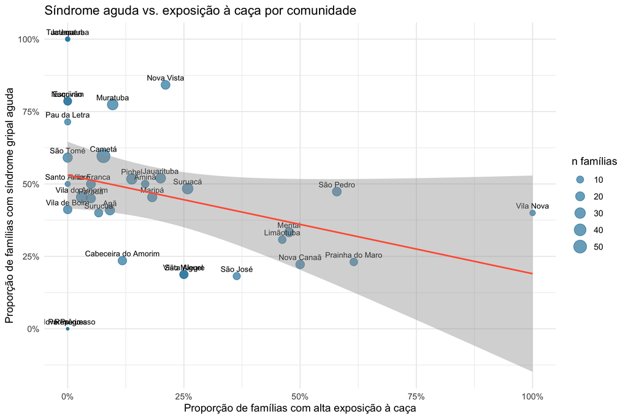

Síndrome aguda vs exposição à caça por comunidade. A linha de regressão é negativa, sendo talvez mais um indício para o isolamento geográfico.

```r
dados_comunidade %>%
  ggplot(aes(x = prop_alta_exp, y = prop_sind_aguda, label = Comunidade)) +
  geom_point(aes(size = n), alpha = 0.7, color = "#2E86AB") +
  geom_text(size = 2.8, vjust = -0.8, hjust = 0.5) +
  geom_smooth(method = "lm", se = TRUE, color = "tomato", linewidth = 0.8) +
  scale_x_continuous(labels = percent) +
  scale_y_continuous(labels = percent) +
  theme_minimal() +
  labs(title = "Síndrome aguda vs. exposição à caça por comunidade",
       x = "Proporção de famílias com alta exposição à caça",
       y = "Proporção de famílias com síndrome gripal aguda",
       size = "n famílias")
```

# 6 P4 — Desvendando o gradiente negativo

A associação negativa observada no scatter plot é contra-intuitiva. Testamos se ela é explicada por variáveis de composição familiar e remoticidade.

**Ver código**

```r
m1 <- lm(prop_sind_aguda ~ prop_alta_exp,
         data = dados_comunidade, weights = n)
m2 <- lm(prop_sind_aguda ~ prop_alta_exp + prop_com_crianca,
         data = dados_comunidade, weights = n)
m3 <- lm(prop_sind_aguda ~ prop_alta_exp + prop_com_crianca + prop_agua_rio,
         data = dados_comunidade, weights = n)
```

**Ver código**

```r
map_dfr(list(m1 = m1, m2 = m2, m3 = m3), tidy, .id = "modelo") %>%
  filter(term != "(Intercept)") %>%
  select(modelo, term, estimate, p.value) %>%
  mutate(
    estimate = round(estimate, 3),
    p.value  = round(p.value, 3),
    term = recode(term,
      "prop_alta_exp"    = "Caça intensa",
      "prop_com_crianca" = "Famílias c/ crianças",
      "prop_agua_rio"    = "Água do rio"
    )
  ) %>%
  kable()
```

Coeficientes dos modelos de regressão ponderada por comunidade. O efeito da caça desaparece progressivamente quando variáveis de composição familiar e remoticidade entram no modelo.

| modelo | term | estimate | p.value |
| --- | --- | --- | --- |
| m1 | Caça intensa | -0.453 | 0.006 |
| m2 | Caça intensa | -0.216 | 0.162 |
| m2 | Famílias c/ crianças | 0.142 | 0.675 |
| m3 | Caça intensa | -0.033 | 0.870 |
| m3 | Famílias c/ crianças | -0.023 | 0.949 |
| m3 | Água do rio | -0.164 | 0.197 |

**Ver código**

```r
  # rename(Modelo = modelo, Variável = term, Estimativa = estimate, p-valor = p.value) %>%
  # kable(align = c("l", "l", "r", "r")) %>%
  # kable_styling(bootstrap_options = c("striped", "hover"), full_width = FALSE) %>%
  # row_spec(which(.$`p-valor` < 0.05), bold = TRUE)
```

**Ver código**

```r
map_dfr(list(m1 = m1, m2 = m2, m3 = m3), glance, .id = "modelo") %>%
  select(modelo, r.squared, adj.r.squared, p.value) %>%
  mutate(across(where(is.numeric), ~ round(., 3))) %>%
  kable()
```

Comparação de modelos — R² e significância global.

| modelo | r.squared | adj.r.squared | p.value |
| --- | --- | --- | --- |
| m1 | 0.208 | 0.184 | 0.006 |
| m2 | 0.123 | 0.014 | 0.349 |
| m3 | 0.219 | 0.062 | 0.282 |

**Ver código**

```r
  # rename(Modelo = modelo, R² = r.squared, `R² ajustado` = adj.r.squared, `p-valor` = p.value) %>%
  # kable(align = c("l", "r", "r", "r")) %>%
  # kable_styling(bootstrap_options = c("striped", "hover"), full_width = FALSE)
```

**Ver código**

```r
cor_agua  <- cor.test(dados_comunidade$prop_alta_exp, dados_comunidade$prop_agua_rio, method = "spearman")
cor_crian <- cor.test(dados_comunidade$prop_alta_exp, dados_comunidade$prop_com_crianca, method = "spearman")
```

**Interpretação — P4**

O efeito da caça desaparece completamente quando variáveis de remoticidade entram no modelo (β = -0,03; p = 0,87 no m3). Caça intensa e uso de água do rio são proxies do mesmo fenômeno subjacente — **isolamento geográfico** (ρ = 0.68, p < 0,001). Comunidades mais remotas caçam mais, dependem de água do rio, e têm menor circulação de vírus respiratório humano.

# 7 P5 — Composição familiar e saneamento

A ideia aqui é verificar se a composição as variáveis sociodemográficas disponíveis poderiam ajudar a explicar o efeito do sindrome aguda.

**Ver código**

```r
dados_integrados %>%
  group_by(cluster_label) %>%
  summarise(
    `Famílias c/ crianças` = percent(mean(tem_crianca,    na.rm = TRUE), accuracy = 1),
    `Média de crianças`    = round(mean(CSCRIANC,         na.rm = TRUE), 1),
    `Ferve água`           = percent(mean(ferve_agua,     na.rm = TRUE), accuracy = 1),
    `Filtra água`          = percent(mean(filtra_agua,    na.rm = TRUE), accuracy = 1),
    `Água do rio`          = percent(mean(agua_rio,       na.rm = TRUE), accuracy = 1),
    `Casa precária`        = percent(mean(casa_precaria,  na.rm = TRUE), accuracy = 1),
    n = n()
  ) %>%
  rename(Cluster = cluster_label) %>%
  kable(align = c("l", rep("r", 7))) %>%
  kable_styling(bootstrap_options = c("striped", "hover"), full_width = FALSE)
```

Variáveis domiciliares por cluster sindrômico. Presença de crianças é o único preditor consistente.

| Cluster | Famílias c/ crianças | Média de crianças | Ferve água | Filtra água | Água do rio | Casa precária | n |
| --- | --- | --- | --- | --- | --- | --- | --- |
| Sem síndrome aguda predominante | 62% | 1.6 | 20% | 51% | 21% | 23% | 292 |
| Síndrome gripal/infecciosa aguda | 83% | 2.1 | 31% | 59% | 12% | 22% | 275 |

## 7.1 Atividade do chefe da família

A atividade do chefe de família (respondente do questionário) pode estar relacionada à o cluster de síndrome aguda? talvez professores que estão em contato com crianças são aqueles responsáveis pela transmissão?

**Ver código**

```r
atividades_vars <- c("AGSAUDE", "ARTESANAT", "COMERC",
                     "EXTRAT", "PESCA", "PROFESSOR", "ROÇA")

dados_integrados %>%
  group_by(cluster_label) %>%
  summarise(across(all_of(atividades_vars),
                   ~ percent(mean(., na.rm = TRUE), accuracy = 1))) %>%
  rename(Cluster = cluster_label) %>%
  kable(align = c("l", rep("r", length(atividades_vars)))) %>%
  kable_styling(bootstrap_options = c("striped", "hover"), full_width = FALSE)
```

Prevalência das atividades do chefe da família por cluster. Diferenças de 1–8 pontos percentuais em todas as categorias — sem padrão direcional.

| Cluster | AGSAUDE | ARTESANAT | COMERC | EXTRAT | PESCA | PROFESSOR | ROÇA |
| --- | --- | --- | --- | --- | --- | --- | --- |
| Sem síndrome aguda predominante | 3% | 16% | 7% | 43% | 38% | 11% | 85% |
| Síndrome gripal/infecciosa aguda | 2% | 17% | 5% | 35% | 41% | 10% | 89% |

**Interpretação — P6**

Presença de crianças é o preditor mais consistente da síndrome aguda: 83% das famílias no cluster 2 têm crianças (média 2,1) vs 62% no cluster 1 (média 1,6). Crianças são os principais amplificadores intradomiciliares de vírus respiratórios. Saneamento, condição da casa e ocupação do chefe **não diferenciam** os clusters de forma consistente. Nem agente de saúde, nem professor, atividades talvez com maior mobilidade, apresentam prevalências distintas entre os grupos.

# 8 Análise espacial — conectividade fluvial

A análise não-espacial deixou a hipótese de remoticidade em aberto. Com as coordenadas das comunidades, verificamos diretamente se a distância ao rio Tapajós, utilizado como proxy de remoticidade por ser a principal via de conectividade fluvial da RESEX, explica os padrões observados.

**Ver código**

```r
pontos <- read_sf("./pontos_resex_sisgeo.gpkg")

dicionario <- tribble(
  ~nome_ponto,  ~Comunidade,
  "amina",      "Aminã",        "ana",        "Anã",
  "cabec_amor", "Cabeceira do Amorim", "cameta",     "Cametá",
  "escrivao",   "Escrivão",     "jaca",       "Jaca",
  "jatequara",  "Jatequara",    "jauarituba", "Jauarituba",
  "limaotuba",  "Limãotuba",    "maripa",     "Maripá",
  "mentai",     "Mentai",       "muratuba",   "Muratuba",
  "nova_vista", "Nova Vista",   "novo_canaa", "Nova Canaã",
  "novo_progr", "Novo Progresso", "nuquini",  "Nuquinim",
  "paranapixu", "Parapixuna",   "paraua",     "Parauá",
  "pau_letra",  "Pau da Letra", "pinhel",     "Pinhel",
  "prain_maro", "Prainha do Maro", "sao_miguel", "São Miguel",
  "sao_pedro",  "São Pedro",    "sao_tome",   "São Tomé",
  "suruaca",    "Suruaca",      "surucuá",    "Surucuá",
  "tucumatuba", "Tucumatuba",   "vila_amori", "Vila do Amorim",
  "vila_boim",  "Vila de Boim", "vila_franc", "Vila Franca",
  "vila_nova",  "Vila Nova",    "vista_aleg", "Vista Alegre"
)

arapiuns <- c("Nova Canaã", "Vista Alegre", "Prainha do Maro", "Vila Nova",
              "Mentai", "Nova Vista", "Aminã", "São Pedro")

pontos_limpo <- pontos %>%
  left_join(dicionario, by = c("nome" = "nome_ponto")) %>%
  na.omit() %>%
  mutate(
    lon   = st_coordinates(geom)[, 1],
    lat   = st_coordinates(geom)[, 2],
    bacia = case_when(
      Comunidade %in% arapiuns ~ "Arapiuns",
      TRUE                     ~ "Tapajós"
    )
  )

reserva_shp <- read_sf("./resex_tapajos_arapiuns.kml") %>%
  select(-Description) %>%
  mutate(Name = "resex")

# Rio Tapajós
rios <- ne_download(scale = 10, type = "rivers_lake_centerlines",
                    category = "physical", returnclass = "sf")
tapajos_rio <- rios %>%
  filter(str_detect(name, "Tapajós|Tapajos")) %>%
  st_transform(st_crs(pontos_limpo))

pontos_limpo <- pontos_limpo %>%
  mutate(
    dist_tapajos_km = as.numeric(st_distance(geom, tapajos_rio)) / 1000
  )
```

**Ver código**

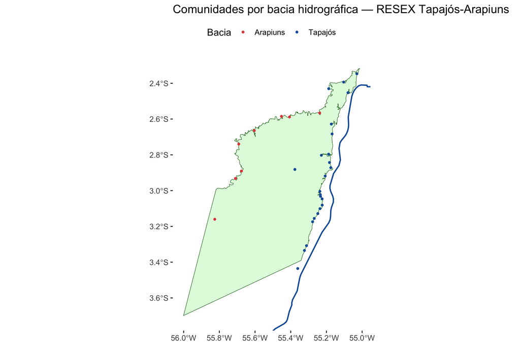

```r
# Obter os limites da reserva
bbox <- st_bbox(reserva_shp)

# Adicionar uma margem de 5% ao redor da reserva
x_range <- bbox[3] - bbox[1]
y_range <- bbox[4] - bbox[2]

zoom_x <- c(bbox[1] - 0.01 * x_range, bbox[3] + 0.01 * x_range)
zoom_y <- c(bbox[2] - 0.01 * y_range, bbox[4] + 0.01 * y_range)

ggplot() +
  # geom_sf(data = pa, fill = "grey", alpha = 0.5) +
  geom_sf(data = reserva_shp, fill = "lightgreen", alpha = 0.3,
          color = "darkgreen") +
  geom_sf(data = tapajos_rio, color = "#185FA5", linewidth = 0.8) +
  geom_sf(data = pontos_limpo, aes(color = bacia), size = 1) +
  # geom_sf_text(data = pontos_limpo, aes(label = Comunidade),
  #              size = 2.5, vjust = -0.8) +
  scale_color_manual(values = c("Arapiuns" = "#E24B4A",
                                "Tapajós" = "#185FA5"),
                     name = "Bacia") +
  coord_sf(xlim = zoom_x, ylim = zoom_y) +  # Aplica o zoom
  ggpubr::theme_pubclean() +
  labs(title = "Comunidades por bacia hidrográfica — RESEX Tapajós-Arapiuns")
```

**Ver código**

```r
dados_comunidade_limpo <- dados_comunidade %>%
  left_join(
    pontos_limpo %>%
      st_drop_geometry() %>%
      select(Comunidade, bacia, dist_tapajos_km),
    by = "Comunidade"
  ) %>%
  mutate(arapiuns = as.integer(bacia == "Arapiuns")) %>%
  na.omit()
```

## 8.1 Arapiuns vs Tapajós

**Ver código**

```r
w_exp   <- wilcox.test(prop_alta_exp   ~ bacia, data = dados_comunidade_limpo)
w_sind  <- wilcox.test(prop_sind_aguda ~ bacia, data = dados_comunidade_limpo)
w_agua  <- wilcox.test(prop_agua_rio   ~ bacia, data = dados_comunidade_limpo)

dados_comunidade_limpo %>%
  group_by(bacia) %>%
  summarise(
    `n comunidades`   = n(),
    `Alta exposição`  = percent(mean(prop_alta_exp,   na.rm = TRUE), accuracy = 1),
    `Síndrome aguda`  = percent(mean(prop_sind_aguda, na.rm = TRUE), accuracy = 1),
    `Água do rio`     = percent(mean(prop_agua_rio,   na.rm = TRUE), accuracy = 1)
  ) %>%
  rename(Bacia = bacia) %>%
  kable(align = c("l", rep("r", 4))) %>%
  kable_styling(bootstrap_options = c("striped", "hover"), full_width = FALSE) %>%
  footnote(general = paste0(
    "Wilcoxon: Alta exposição p=", round(w_exp$p.value, 3),
    " | Síndrome aguda p=", round(w_sind$p.value, 3),
    " | Água do rio p=", round(w_agua$p.value, 3)
  ))
```

Comparação entre bacias — Arapiuns caça mais (p=0,003) mas não tem mais síndrome aguda (p=0,845).

| Bacia | n comunidades | Alta exposição | Síndrome aguda | Água do rio |
| --- | --- | --- | --- | --- |
| Arapiuns | 7 | 51% | 34% | 51% |
| Tapajós | 10 | 13% | 34% | 17% |

Note:  
Wilcoxon: Alta exposição p=0.003 | Síndrome aguda p=0.845 | Água do rio p=0.07

## 8.2 Distância ao Tapajós

**Ver código**

```r
cor_exp  <- cor.test(dados_comunidade_limpo$dist_tapajos_km, dados_comunidade_limpo$prop_alta_exp,   method = "spearman")
cor_sind <- cor.test(dados_comunidade_limpo$dist_tapajos_km, dados_comunidade_limpo$prop_sind_aguda, method = "spearman")
cor_agua2 <- cor.test(dados_comunidade_limpo$dist_tapajos_km, dados_comunidade_limpo$prop_agua_rio,  method = "spearman")
```

**Ver código**

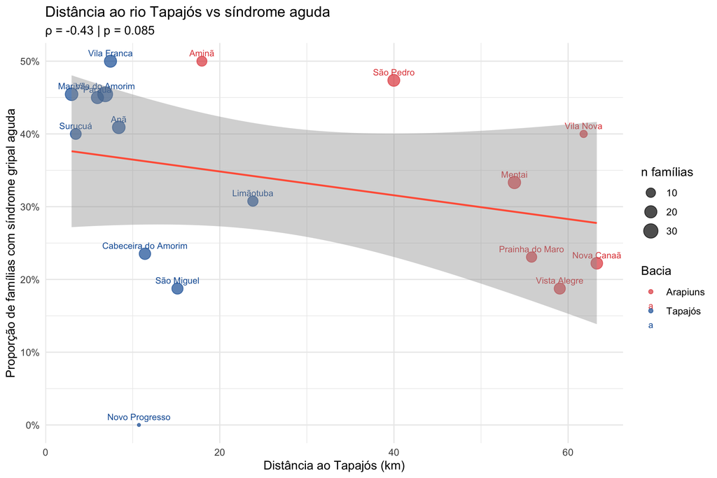

Distância ao rio Tapajós vs síndrome aguda por bacia. Comunidades mais próximas ao Tapajós tendem a ter mais síndrome aguda (ρ=-0,43; p=0,085).

```r
dados_comunidade_limpo %>%
  ggplot(aes(x = dist_tapajos_km, y = prop_sind_aguda,
             label = Comunidade, color = bacia)) +
  geom_point(aes(size = n), alpha = 0.7) +
  geom_text(size = 2.8, vjust = -0.8) +
  geom_smooth(method = "lm", se = TRUE, color = "tomato",
              linewidth = 0.8, aes(group = 1)) +
  scale_y_continuous(labels = percent) +
  scale_color_manual(values = c("Arapiuns" = "#E24B4A", "Tapajós" = "#185FA5")) +
  theme_minimal() +
  labs(title = "Distância ao rio Tapajós vs síndrome aguda",
       subtitle = paste0("ρ = ", round(cor_sind$estimate, 2),
                         " | p = ", round(cor_sind$p.value, 3)),
       x = "Distância ao Tapajós (km)",
       y = "Proporção de famílias com síndrome gripal aguda",
       size = "n famílias", color = "Bacia")
```

## 8.3 Modelo final

**Ver código**

```r
m_bacia   <- lm(prop_sind_aguda ~ prop_alta_exp + prop_com_crianca + arapiuns,
                data = dados_comunidade_limpo, weights = n)
m_tapajos <- lm(prop_sind_aguda ~ prop_alta_exp + prop_com_crianca + dist_tapajos_km,
                data = dados_comunidade_limpo, weights = n)
```

**Ver código**

```r
map_dfr(list(
  m1 = m1, m2 = m2, m3 = m3,
  m_bacia = m_bacia, m_tapajos = m_tapajos
), glance, .id = "modelo") %>%
  select(modelo, r.squared, adj.r.squared, p.value) %>%
  mutate(across(where(is.numeric), ~ round(., 3))) %>%
  kable()
```

| modelo | r.squared | adj.r.squared | p.value |
| --- | --- | --- | --- |
| m1 | 0.208 | 0.184 | 0.006 |
| m2 | 0.123 | 0.014 | 0.349 |
| m3 | 0.219 | 0.062 | 0.282 |
| m_bacia | 0.126 | -0.076 | 0.613 |
| m_tapajos | 0.335 | 0.181 | 0.139 |

**Ver código**

```r
  # rename(Modelo = modelo, R² = r.squared, `R² ajustado` = adj.r.squared, `p-valor` = p.value) %>%
  # kable(align = c("l", "r", "r", "r")) %>%
  # kable_styling(bootstrap_options = c("striped", "hover"), full_width = FALSE) %>%
  # row_spec(5, bold = TRUE, background = "#EAF3DE")
```

**Ver código**

```r
tidy(m_tapajos) %>%
  filter(term != "(Intercept)") %>%
  mutate(
    term = recode(term,
      "prop_alta_exp"    = "Caça intensa",
      "prop_com_crianca" = "Famílias c/ crianças",
      "dist_tapajos_km"  = "Distância ao Tapajós (km)"
    ),
    across(c(estimate, std.error, statistic, p.value), ~ round(., 3))
  ) %>%
  rename(Variável = term, Estimativa = estimate, EP = std.error,
         `t` = statistic, `p-valor` = p.value) %>%
  kable(align = c("l", rep("r", 4))) %>%
  kable_styling(bootstrap_options = c("striped", "hover"), full_width = FALSE)
```

Modelo final (m_tapajos). Distância ao Tapajós: β=-0,004; p=0,064. Caça perde efeito quando conectividade fluvial é controlada.

| Variável | Estimativa | EP | t | p-valor |
| --- | --- | --- | --- | --- |
| Caça intensa | 0.193 | 0.218 | 0.884 | 0.393 |
| Famílias c/ crianças | -0.172 | 0.433 | -0.397 | 0.698 |
| Distância ao Tapajós (km) | -0.004 | 0.002 | -2.027 | 0.064 |

## 8.4 Mapas finais

**Ver código**

```r
dados_espaciais <- dados_comunidade_limpo %>%
  left_join(pontos_limpo %>% select(Comunidade, geom), by = "Comunidade") %>%
  st_as_sf()
```

**Ver código**

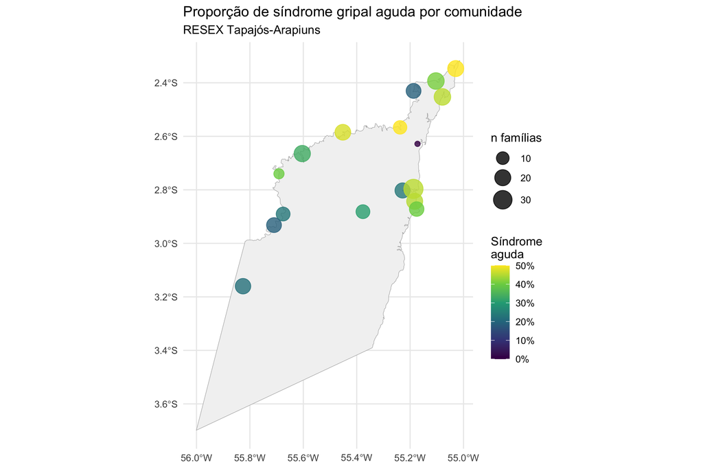

Proporção de síndrome gripal aguda por comunidade na RESEX Tapajós-Arapiuns.

```r
ggplot() +
  geom_sf(data = reserva_shp, fill = "grey95", color = "grey70") +
  geom_sf(data = dados_espaciais, aes(size = n, color = prop_sind_aguda), alpha = 0.8) +
  scale_color_viridis_c(labels = percent, name = "Síndrome\naguda") +
  scale_size_continuous(name = "n famílias", range = c(2, 8)) +
  theme_minimal() +
  labs(title = "Proporção de síndrome gripal aguda por comunidade",
       subtitle = "RESEX Tapajós-Arapiuns")
```

**Ver código**

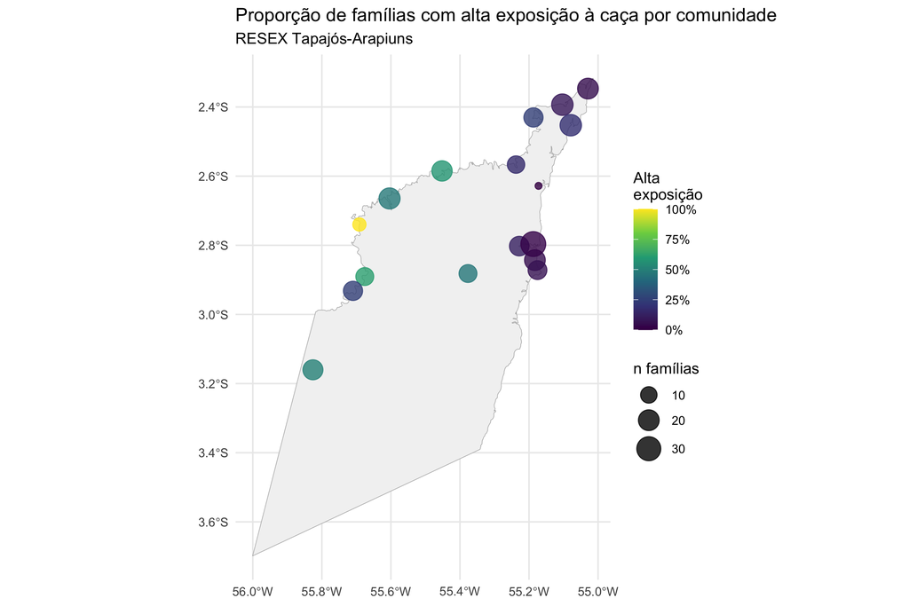

Proporção de famílias com alta exposição à caça por comunidade.

```r
ggplot() +
  geom_sf(data = reserva_shp, fill = "grey95", color = "grey70") +
  geom_sf(data = dados_espaciais, aes(size = n, color = prop_alta_exp), alpha = 0.8) +
  scale_color_viridis_c(labels = percent, name = "Alta\nexposição") +
  scale_size_continuous(name = "n famílias", range = c(2, 8)) +
  theme_minimal() +
  labs(title = "Proporção de famílias com alta exposição à caça por comunidade",
       subtitle = "RESEX Tapajós-Arapiuns")
```

# 9 Síntese dos achados

**Ver código**

```r
tibble(
  `#` = paste0("P", 1:6),
  Pergunta = c(
    "Qual é o perfil sindrômico das famílias?",
    "Existe gradiente de exposição zoonótica?",
    "A caça prediz síndrome infecciosa aguda?",
    "O gradiente negativo é confundido por remoticidade?",
    "Composição etária explica a síndrome aguda?",
    "Atividade do chefe diferencia os clusters?"
  ),
  Resultado = c(
    "Confirmado",
    "Confirmado",
    "Refutado",
    "Confirmado",
    "Parcialmente confirmado",
    "Refutado"
  ),
  `Achado principal` = c(
    "k=2: síndrome gripal/infecciosa aguda (49%) vs sem síndrome aguda (51%). χ²=78; p<0,001 entre comunidades.",
    "Alta exposição: 44% de contato com animal doente vs 18% baixa (χ²=22,2; p<0,001). VERMES mais prevalente (12%).",
    "Nenhuma variável de caça se associa ao cluster (p>0,05). Consumo de animal doente: OR=0,65; p=0,046 — efeito inverso.",
    "Caça e água do rio são proxies de isolamento (ρ=0,68; p<0,001). Bacia Arapiuns caça mais (p=0,003) mas sem mais síndrome aguda (p=0,845). Distância ao Tapajós: β=-0,004; p=0,064.",
    "Famílias com crianças: 83% vs 62% entre clusters (média 2,1 vs 1,6). Saneamento e casa não diferenciam.",
    "Diferenças de 1–8 pp em todas as atividades — sem padrão."
  )
) %>%
  kable(align = c("c", "l", "c", "l")) %>%
  kable_styling(bootstrap_options = c("striped", "hover"), full_width = TRUE) %>%
  column_spec(3, bold = TRUE,
              color = ifelse(
                c("Confirmado", "Confirmado", "Refutado",
                  "Confirmado", "Parcialmente confirmado", "Refutado") == "Confirmado",
                "#27500A",
                ifelse(
                  c("Confirmado", "Confirmado", "Refutado",
                    "Confirmado", "Parcialmente confirmado", "Refutado") == "Refutado",
                  "#791F1F", "#633806"
                )
              ))
```

Síntese das perguntas de pesquisa e achados principais.

[output not shown]

**Diagrama “causal”**

[output not shown]

# 10 Limitações

**Limitações da análise**